# Project 1: Nutrition and Weight

Exploratory Data Analysis and Statistical Inference

Published

March 18, 2026

# 1 Data Overview

The dataset records nutritional and growth information on babies born at the Queen Mother’s Hospital, Glasgow. After loading, we check the structure, missing values, and basic distributions before proceeding to modelling.

```r
str(data)
```

```
'data.frame':   113 obs. of  5 variables:
 $ Sex    : Factor w/ 2 levels "Female","Male": 2 1 2 1 1 1 1 2 2 2 ...
 $ Wt1    : num  4.34 3.52 5.14 4.66 4.44 4.64 3.92 4.98 5 3.82 ...
 $ Wt24   : num  11.4 10.6 12.5 12.3 13.1 ...
 $ Solids : int  10 13 15 16 14 8 12 12 11 20 ...
 $ Wt_Diff: num  7.11 7.03 7.36 7.64 8.66 7.61 8.53 8.42 7.35 8.78 ...
```

```r
colSums(is.na(data))
```

```
    Sex     Wt1    Wt24  Solids Wt_Diff
      0       0       0       0       0
```

```r
summary(data)
```

```
     Sex          Wt1             Wt24           Solids         Wt_Diff
 Female:49   Min.   :3.140   Min.   : 8.46   Min.   : 4.00   Min.   : 4.800
 Male  :64   1st Qu.:4.000   1st Qu.:11.55   1st Qu.:10.00   1st Qu.: 7.510
             Median :4.340   Median :12.50   Median :12.00   Median : 8.290
             Mean   :4.337   Mean   :12.61   Mean   :11.47   Mean   : 8.268
             3rd Qu.:4.700   3rd Qu.:13.50   3rd Qu.:13.00   3rd Qu.: 8.980
             Max.   :5.940   Max.   :17.90   Max.   :22.00   Max.   :12.620
```

**Key observations:**

- The CSV contains **113 complete observations** (the study description states 127; 14 records appear absent from this file).
- **Sex** is a binary factor: 64 males (56.6%) and 49 females (43.4%).
- **Wt1** ranges from 3.14 to 5.94 kg (mean 4.34 kg); **Wt24** from 8.46 to 17.90 kg (mean 12.61 kg).
- **Solids** ranges from 4 to 22 months (mean 11.5 months), right-skewed with a cluster around 11–13 months.
- No missing values are present.

```r
tbl <- data.frame(
  Sex        = c("Female", "Male"),
  N          = as.integer(table(data$Sex)),
  Proportion = round(prop.table(table(data$Sex)), 3)
)
knitr::kable(tbl, caption = "Table 1. Sex distribution in the sample.")
```

Table 1. Sex distribution in the sample.

| Sex | N | Proportion.Var1 | Proportion.Freq |
| --- | --- | --- | --- |
| Female | 49 | Female | 0.434 |
| Male | 64 | Male | 0.566 |

## 1.1 Univariate Distributions

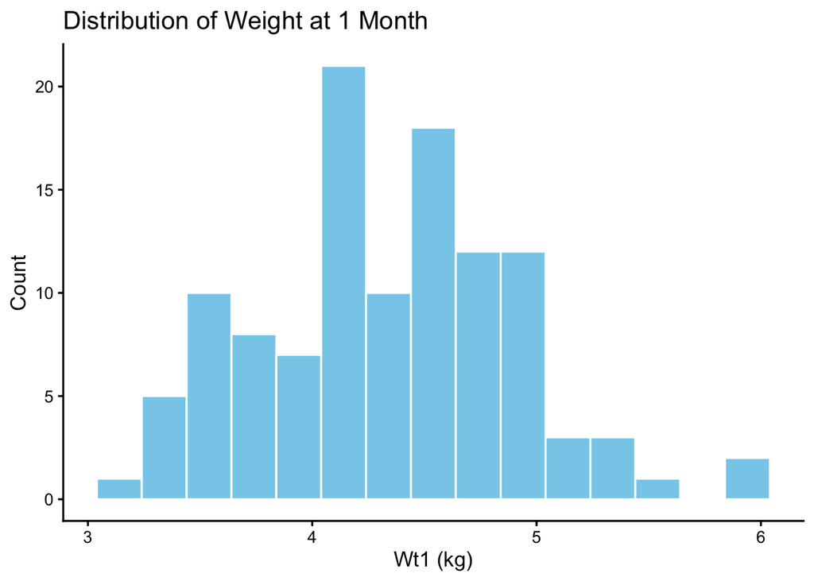

Figure 1. Distribution of weight at 1 month.

```r
ggplot(data, aes(x = Wt1)) +
  geom_histogram(bins = 15, colour = "white", fill = "#87CEEB") +
  labs(title = "Distribution of Weight at 1 Month",
       x = "Wt1 (kg)", y = "Count") +
  theme_classic(base_size = 13)
```

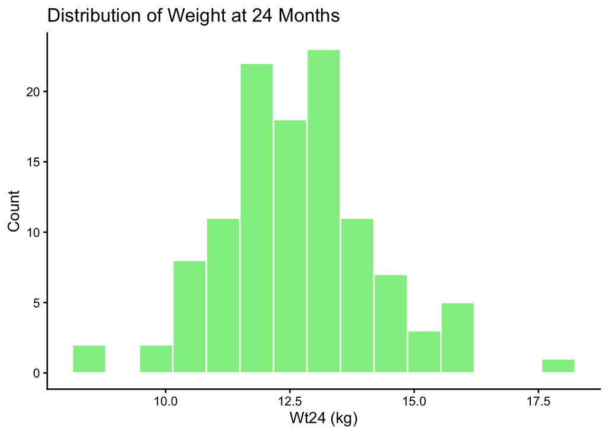

Figure 2. Distribution of weight at 24 months.

```r
ggplot(data, aes(x = Wt24)) +
  geom_histogram(bins = 15, colour = "white", fill = "#90EE90") +
  labs(title = "Distribution of Weight at 24 Months",
       x = "Wt24 (kg)", y = "Count") +
  theme_classic(base_size = 13)
```

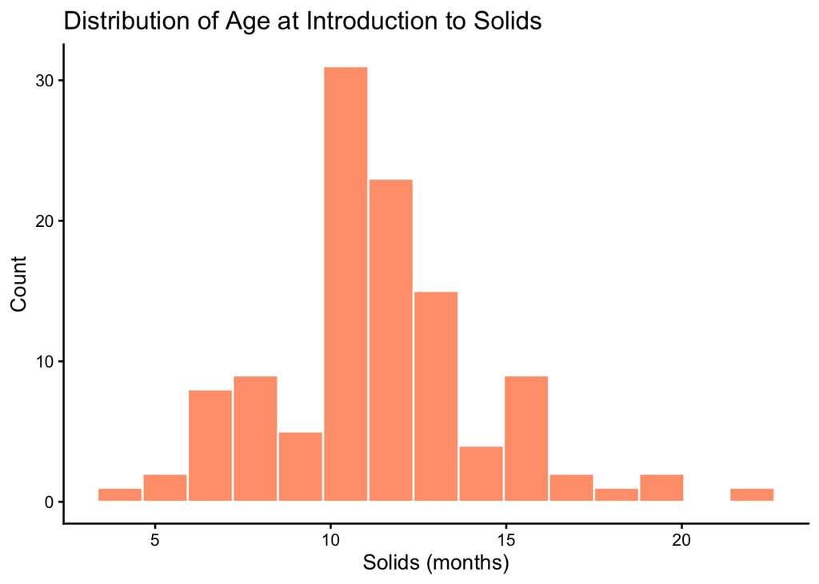

Figure 3. Distribution of age at introduction to solids.

```r
ggplot(data, aes(x = Solids)) +
  geom_histogram(bins = 15, colour = "white", fill = "#FFA07A") +
  labs(title = "Distribution of Age at Introduction to Solids",
       x = "Solids (months)", y = "Count") +
  theme_classic(base_size = 13)
```

## 1.2 Relationship between Wt1 and Wt24

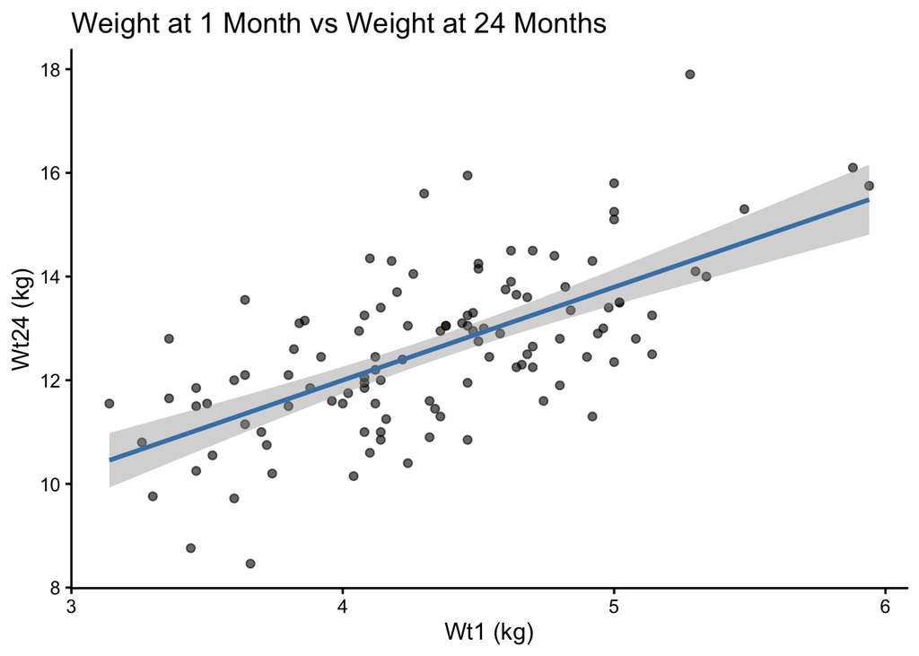

Figure 4. Scatterplot of Wt1 vs Wt24 with OLS regression line.

```r
ggplot(data, aes(x = Wt1, y = Wt24)) +
  geom_point(alpha = 0.6) +
  geom_smooth(method = "lm", se = TRUE, colour = "steelblue") +
  labs(title = "Weight at 1 Month vs Weight at 24 Months",
       x = "Wt1 (kg)", y = "Wt24 (kg)") +
  theme_classic(base_size = 13)
```

Figure 4 shows a clear **positive linear association** between Wt1 and Wt24. Heavier babies at 1 month tend to be heavier at 24 months, though the scatter around the line is considerable, indicating that Wt1 alone does not explain all the variation.

# 2 Question 1 — Simple Linear Regression

> *How well can weight at 24 months be predicted using weight at 1 month alone?*

## 2.1 Model Fitting

```r
model1 <- lm(Wt24 ~ Wt1, data = data)
summary(model1)
```

```
Call:
lm(formula = Wt24 ~ Wt1, data = data)

Residuals:
    Min      1Q  Median      3Q     Max
-2.9294 -0.7976 -0.0937  0.7234  3.6010

Coefficients:
            Estimate Std. Error t value Pr(>|t|)
(Intercept)   4.8159     0.8780   5.485 2.63e-07 ***
Wt1           1.7960     0.2008   8.946 9.46e-15 ***
---
Signif. codes:  0 '***' 0.001 '**' 0.01 '*' 0.05 '.' 0.1 ' ' 1

Residual standard error: 1.202 on 111 degrees of freedom
Multiple R-squared:  0.419, Adjusted R-squared:  0.4137
F-statistic: 80.03 on 1 and 111 DF,  p-value: 9.456e-15
```

**Model equation:**

$$\widehat{\text{Wt24}} = 4.816 + 1.796 \times \text{Wt1}$$

- **R² = 0.419** — Wt1 explains approximately 42% of the variability in Wt24.
- **Adjusted R² = 0.414**
- The slope is statistically significant (*p* < 0.001): each additional kilogram of weight at 1 month is associated with an expected increase of **1.80 kg** at 24 months.

## 2.2 Diagnostic Plots

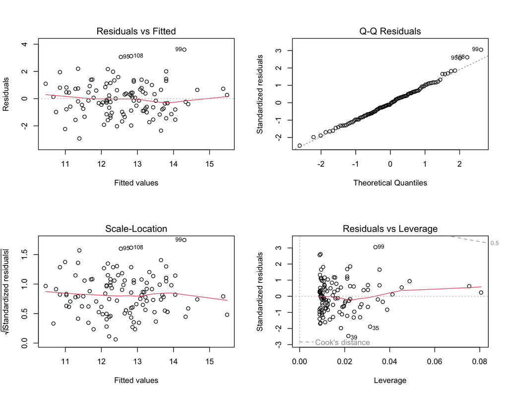

Figure 5. Regression diagnostics for model 1 (Wt24 ~ Wt1).

```r
par(mfrow = c(2, 2))
plot(model1)
```

```r
par(mfrow = c(1, 1))
```

**Interpretation of diagnostics:**

- **Residuals vs Fitted:** Points are scattered roughly horizontally around zero with no obvious curvature, supporting the linearity assumption.
- **Normal Q-Q:** Residuals lie closely along the reference line except for a couple of points in the upper tail (e.g., observation 99 with an unusually high Wt24 of 17.9 kg). Overall normality is reasonable.
- **Scale-Location:** The spread of residuals is broadly constant across fitted values, consistent with homoscedasticity.
- **Residuals vs Leverage:** No observation exerts unduly high leverage or has a Cook’s distance close to 1; the model is not driven by outliers.

## 2.3 Conclusion — Q1

The simple linear regression of Wt24 on Wt1 is statistically significant and provides a **moderate fit (R² ≈ 0.42)**. While weight at 1 month is a useful predictor of weight at 24 months, roughly 58% of the variation remains unexplained, motivating the inclusion of additional variables in Q2.

# 3 Question 2 — Multiple Linear Regression

> *Would the model be improved by adding Sex and/or age at introduction to solids?*

We fit three extended models and compare them to Model 1 via F-tests (ANOVA) and AIC.

## 3.1 Model Fitting

```r
weight_sex_model  <- lm(Wt24 ~ Wt1 + Sex,           data = data)
weight_age_model  <- lm(Wt24 ~ Wt1 + Solids,        data = data)
weight_comb_model <- lm(Wt24 ~ Wt1 + Sex + Solids,  data = data)

summary(weight_sex_model)
```

```
Call:
lm(formula = Wt24 ~ Wt1 + Sex, data = data)

Residuals:
    Min      1Q  Median      3Q     Max
-2.7385 -0.7790 -0.0158  0.7462  3.5246

Coefficients:
            Estimate Std. Error t value Pr(>|t|)
(Intercept)   5.2264     0.8821   5.925 3.64e-08 ***
Wt1           1.6317     0.2106   7.749 4.95e-12 ***
SexMale       0.5336     0.2392   2.230   0.0277 *
---
Signif. codes:  0 '***' 0.001 '**' 0.01 '*' 0.05 '.' 0.1 ' ' 1

Residual standard error: 1.181 on 110 degrees of freedom
Multiple R-squared:  0.4441,    Adjusted R-squared:  0.434
F-statistic: 43.94 on 2 and 110 DF,  p-value: 9.44e-15
```

```r
summary(weight_age_model)
```

```
Call:
lm(formula = Wt24 ~ Wt1 + Solids, data = data)

Residuals:
    Min      1Q  Median      3Q     Max
-2.9316 -0.8186 -0.1377  0.7139  3.5269

Coefficients:
            Estimate Std. Error t value Pr(>|t|)
(Intercept)  5.49355    1.04625   5.251 7.46e-07 ***
Wt1          1.75780    0.20297   8.660 4.50e-14 ***
Solids      -0.04463    0.03763  -1.186    0.238
---
Signif. codes:  0 '***' 0.001 '**' 0.01 '*' 0.05 '.' 0.1 ' ' 1

Residual standard error: 1.199 on 110 degrees of freedom
Multiple R-squared:  0.4263,    Adjusted R-squared:  0.4159
F-statistic: 40.87 on 2 and 110 DF,  p-value: 5.347e-14
```

```r
summary(weight_comb_model)
```

```
Call:
lm(formula = Wt24 ~ Wt1 + Sex + Solids, data = data)

Residuals:
    Min      1Q  Median      3Q     Max
-2.7324 -0.7632 -0.0949  0.8210  3.4366

Coefficients:
            Estimate Std. Error t value Pr(>|t|)
(Intercept)  6.01782    1.05004   5.731 8.99e-08 ***
Wt1          1.58071    0.21297   7.422 2.69e-11 ***
SexMale      0.55750    0.23890   2.334   0.0214 *
Solids      -0.05090    0.03699  -1.376   0.1716
---
Signif. codes:  0 '***' 0.001 '**' 0.01 '*' 0.05 '.' 0.1 ' ' 1

Residual standard error: 1.176 on 109 degrees of freedom
Multiple R-squared:  0.4536,    Adjusted R-squared:  0.4386
F-statistic: 30.16 on 3 and 109 DF,  p-value: 2.828e-14
```

## 3.2 Model Comparison

```r
aic_tbl <- AIC(model1, weight_sex_model, weight_age_model, weight_comb_model)
aic_tbl$Model <- c("Wt24 ~ Wt1",
                   "Wt24 ~ Wt1 + Sex",
                   "Wt24 ~ Wt1 + Solids",
                   "Wt24 ~ Wt1 + Sex + Solids")
aic_tbl$R2     <- c(summary(model1)$r.squared,
                    summary(weight_sex_model)$r.squared,
                    summary(weight_age_model)$r.squared,
                    summary(weight_comb_model)$r.squared) |> round(4)
aic_tbl$AdjR2  <- c(summary(model1)$adj.r.squared,
                    summary(weight_sex_model)$adj.r.squared,
                    summary(weight_age_model)$adj.r.squared,
                    summary(weight_comb_model)$adj.r.squared) |> round(4)

knitr::kable(
  aic_tbl[, c("Model", "df", "AIC", "R2", "AdjR2")],
  caption = "Table 2. Model comparison by AIC, R², and Adjusted R².",
  col.names = c("Model", "df", "AIC", "R²", "Adj R²")
)
```

Table 2. Model comparison by AIC, R², and Adjusted R².

|  | Model | df | AIC | R² | Adj R² |
| --- | --- | --- | --- | --- | --- |
| model1 | Wt24 ~ Wt1 | 3 | 366.1588 | 0.4190 | 0.4137 |
| weight_sex_model | Wt24 ~ Wt1 + Sex | 4 | 363.1605 | 0.4441 | 0.4340 |
| weight_age_model | Wt24 ~ Wt1 + Solids | 4 | 366.7233 | 0.4263 | 0.4159 |
| weight_comb_model | Wt24 ~ Wt1 + Sex + Solids | 5 | 363.2141 | 0.4536 | 0.4386 |

```r
cat("--- F-test: adding Sex ---\n");    print(anova(model1, weight_sex_model))
```

```
--- F-test: adding Sex ---
```

```
Analysis of Variance Table

Model 1: Wt24 ~ Wt1
Model 2: Wt24 ~ Wt1 + Sex
  Res.Df    RSS Df Sum of Sq      F  Pr(>F)
1    111 160.25
2    110 153.32  1    6.9341 4.9749 0.02775 *
---
Signif. codes:  0 '***' 0.001 '**' 0.01 '*' 0.05 '.' 0.1 ' ' 1
```

```r
cat("\n--- F-test: adding Solids ---\n"); print(anova(model1, weight_age_model))
```

```
--- F-test: adding Solids ---
```

```
Analysis of Variance Table

Model 1: Wt24 ~ Wt1
Model 2: Wt24 ~ Wt1 + Solids
  Res.Df    RSS Df Sum of Sq      F Pr(>F)
1    111 160.25
2    110 158.23  1    2.0229 1.4063 0.2382
```

```r
cat("\n--- F-test: adding Sex + Solids ---\n"); print(anova(model1, weight_comb_model))
```

```
--- F-test: adding Sex + Solids ---
```

```
Analysis of Variance Table

Model 1: Wt24 ~ Wt1
Model 2: Wt24 ~ Wt1 + Sex + Solids
  Res.Df    RSS Df Sum of Sq      F Pr(>F)
1    111 160.25
2    109 150.70  2    9.5522 3.4545 0.0351 *
---
Signif. codes:  0 '***' 0.001 '**' 0.01 '*' 0.05 '.' 0.1 ' ' 1
```

**Summary of model comparison:**

[output not shown]

## 3.3 Best Model Diagnostics

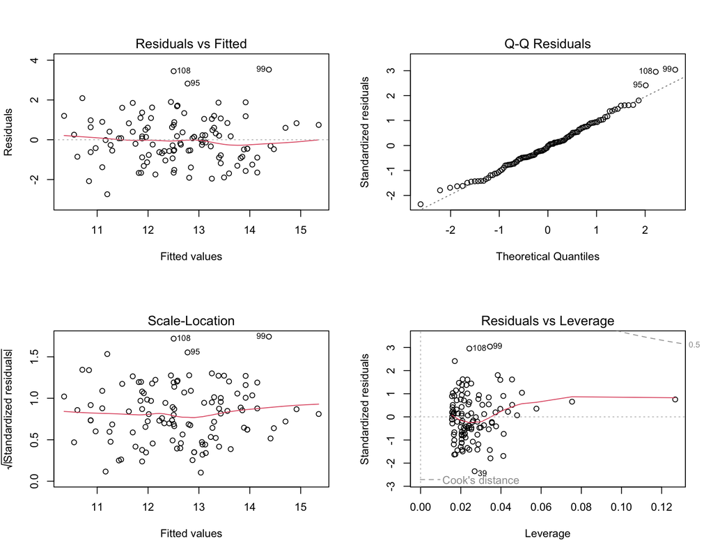

Figure 6. Diagnostics for the best model (Wt24 ~ Wt1 + Sex).

```r
par(mfrow = c(2, 2))
plot(weight_sex_model)
```

```r
par(mfrow = c(1, 1))
```

The diagnostic plots confirm that the residuals are approximately normal, show no systematic pattern against fitted values, and exhibit constant variance — all assumptions of OLS regression are reasonably satisfied.

## 3.4 Conclusion — Q2

Adding **Sex** to the simple model provides a statistically significant and practically meaningful improvement: adjusted R² rises from 0.414 to 0.434 and AIC falls by ~3 units. **Solids**, by contrast, contributes no significant improvement and should be excluded to maintain parsimony. The recommended model is:

$$\widehat{\text{Wt24}} = 5.226 + 1.632 \times \text{Wt1} + 0.534 \times \mathbf{1}[\text{Sex = Male}]$$

# 4 Question 3 — Difference in Weight Gain by Sex

> *What evidence is there that the average change in weight from 1 to 24 months differs between male and female babies?*

## 4.1 Exploratory Analysis

We define weight gain as $\Delta W = \text{Wt24} - \text{Wt1}$ and compare its distribution between sexes.

```r
q3_tbl <- data |>
  group_by(Sex) |>
  summarise(
    N      = n(),
    Mean   = round(mean(Wt_Diff), 3),
    SD     = round(sd(Wt_Diff), 3),
    Median = round(median(Wt_Diff), 3),
    Min    = round(min(Wt_Diff), 2),
    Max    = round(max(Wt_Diff), 2)
  )

knitr::kable(q3_tbl,
  caption  = "Table 3. Summary statistics of weight gain (kg) by sex.",
  col.names = c("Sex", "N", "Mean (kg)", "SD (kg)", "Median (kg)", "Min (kg)", "Max (kg)"))
```

Table 3. Summary statistics of weight gain (kg) by sex.

| Sex | N | Mean (kg) | SD (kg) | Median (kg) | Min (kg) | Max (kg) |
| --- | --- | --- | --- | --- | --- | --- |
| Female | 49 | 7.824 | 1.311 | 7.70 | 4.80 | 11.49 |
| Male | 64 | 8.609 | 1.150 | 8.48 | 6.46 | 12.62 |

Male babies gained on average **8.609 kg** compared to **7.824 kg** for females — a raw difference of **0.785 kg**. Males also show slightly less spread (SD = 1.150) than females (SD = 1.311).

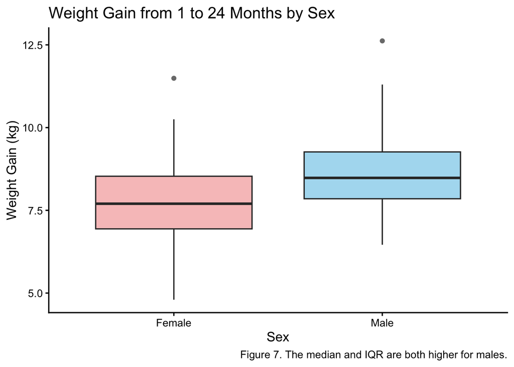

Figure 7. Boxplot of weight gain by sex.

```r
ggplot(data, aes(x = Sex, y = Wt_Diff, fill = Sex)) +
  geom_boxplot(alpha = 0.7, outlier.shape = 16, outlier.size = 2) +
  scale_fill_manual(values = c("Female" = "#F4A9A8", "Male" = "#87CEEB")) +
  labs(title = "Weight Gain from 1 to 24 Months by Sex",
       x = "Sex", y = "Weight Gain (kg)",
       caption = "Figure 7. The median and IQR are both higher for males.") +
  theme_classic(base_size = 13) +
  theme(legend.position = "none")
```

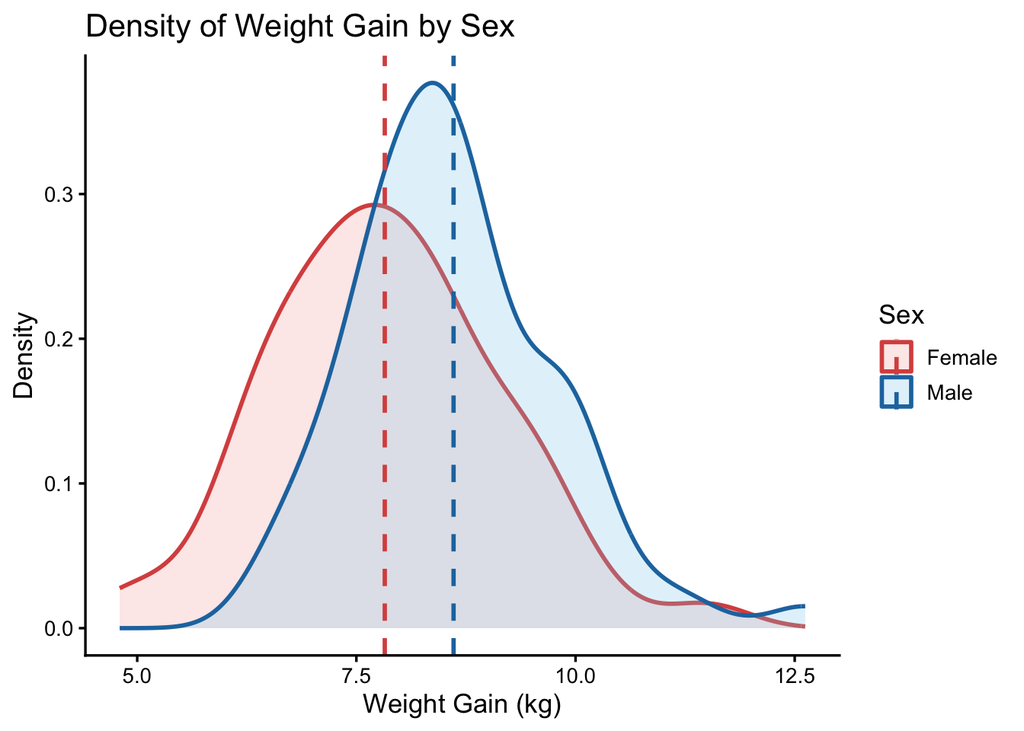

Figure 8. Density curves of weight gain by sex, with dashed mean lines.

```r
mean_df <- data |> group_by(Sex) |> summarise(m = mean(Wt_Diff))

ggplot(data, aes(x = Wt_Diff, colour = Sex, fill = Sex)) +
  geom_density(alpha = 0.25, linewidth = 1) +
  geom_vline(data = mean_df, aes(xintercept = m, colour = Sex),
             linetype = "dashed", linewidth = 1) +
  scale_fill_manual(values   = c("Female" = "#F4A9A8", "Male" = "#87CEEB")) +
  scale_colour_manual(values = c("Female" = "#D9534F", "Male" = "#2176AE")) +
  labs(title = "Density of Weight Gain by Sex",
       x = "Weight Gain (kg)", y = "Density") +
  theme_classic(base_size = 13)
```

**Interpretation of Figures 7 & 8:**  
The boxplot (Figure 7) shows that the male distribution is shifted upward: both the median (≈ 8.48 kg) and the interquartile range sit higher than those of females (median ≈ 7.70 kg). There are no extreme outliers that would distort the analysis. The density plot (Figure 8) reinforces this: the male curve (blue) is displaced to the right of the female curve (red), and the dashed mean lines clearly illustrate the ~0.785 kg gap. Both distributions are approximately bell-shaped, supporting the use of a t-test.

## 4.2 Formal Hypothesis Test

We use a **Welch Two-Sample *t*-test**, which does not assume equal variances — appropriate here given the modest difference in standard deviations and unequal group sizes (n = 64 males, 49 females).

**Hypotheses:**

$$H_0: \mu_{\text{Male}} = \mu_{\text{Female}} \qquad \text{(no difference in mean weight gain)}$$

$$H_1: \mu_{\text{Male}} \neq \mu_{\text{Female}} \qquad \text{(two-sided)}$$

```r
t_test_results <- t.test(Wt_Diff ~ Sex, data = data)
t_test_results
```

```
    Welch Two Sample t-test

data:  Wt_Diff by Sex
t = -3.3234, df = 95.887, p-value = 0.00126
alternative hypothesis: true difference in means between group Female and group Male is not equal to 0
95 percent confidence interval:
 -1.253409 -0.316023
sample estimates:
mean in group Female   mean in group Male
            7.823878             8.608594
```

## 4.3 Conclusion — Q3

The Welch Two-Sample *t*-test yields **t(95.89) = −3.32, p = 0.0013**.

Since *p* = 0.0013 < 0.05, we **reject the null hypothesis**. There is strong statistical evidence that the average weight gain from 1 to 24 months is **not equal** for male and female babies.

The 95% confidence interval for the difference (Female − Male) is **[−1.253, −0.316] kg**. Because the entire interval lies below zero, we can conclude with 95% confidence that males gain **more** weight than females. The estimated difference is approximately **0.785 kg** — modest in absolute terms but statistically robust. This finding aligns with the result from Q2, where Sex was identified as a significant predictor of Wt24 even after controlling for Wt1.

# 5 Overall Summary

| Question | Key Finding |
| --- | --- |
| **Q1** | Wt1 is a significant but moderate predictor of Wt24 (R² = 0.42). A 1 kg increase in Wt1 predicts a 1.80 kg increase in Wt24. |
| **Q2** | Adding **Sex** significantly improves the model (AIC ↓ 3, adj. R² ↑ to 0.434, *p* = 0.028). Adding **Solids** adds no improvement (*p* = 0.238). Best model: Wt24 ~ Wt1 + Sex. |
| **Q3** | Male babies gain on average **0.785 kg more** than female babies (*t* = −3.32, *p* = 0.0013, 95% CI [0.316, 1.253] kg). The difference is statistically significant. |